# Project 1: Urban Ministries of Durham Data

Alfredo Rojas

9/25/2019

This project will be exploring a dataset from the Urban Ministries of Durham (UMD). UMD has provided a .TSV file with information of services provided for their clients over the past couple of decades. In this project I will be exploring two variables: the amount of food provided for clients (in pounds) and the number of clothing items provided. To do so, I will rely on the `tidyverse` and `dplyr` packages, as well as on `ggplot2` for visualization. To start, I will need to upload some packages before I can begin cleaning the data.

```r
library(dplyr)
library(tidyr)
library(stringr)
library(tidyverse)
# install.packages("GGally")
library(GGally)
# install.packages("gridExtra")
library(gridExtra)

# read in data, this Rmd is saved in my "scripts" folder and when I knit it reads automatically
# from "scripts", so I included ".." which brings it out of that directory so it can access #"data"
UMD_data =  read_tsv("../data/UMD_Services_Provided_20190719.tsv")
```

Let’s take a look to see if the data was read in properly.

```r
head(UMD_data)
```

```
## # A tibble: 6 x 18
##   Date  `Client File Nu… `Client File Me… `Bus Tickets (N… `Notes of Servi…
##   <chr>            <dbl>            <dbl>            <dbl> <chr>
## 1 1/22…              212                0               NA <NA>
## 2 1/29…              738                0               NA <NA>
## 3 1/20…             3455                0               NA <NA>
## 4 11/2…             1804            21804               NA <NA>
## 5 12/2…             1806            21806               NA <NA>
## 6 10/1…             1614            21614               NA financial refer…
## # … with 13 more variables: `Food Provided for` <dbl>, `Food
## #   Pounds` <dbl>, `Clothing Items` <dbl>, Diapers <dbl>, `School
## #   Kits` <dbl>, `Hygiene Kits` <dbl>, Referrals <chr>, `Financial
## #   Support` <dbl>, `Type of Bill Paid` <chr>, `Payer of Support` <chr>,
## #   Field1 <lgl>, Field2 <lgl>, Field3 <lgl>
```

Looks good!

## Cleaning the data

The first thing I notice is that some of the variables contain all NAs. Let’s remove them.

```r
# Check the `Field 1 - 3` variables, are they empty?
# from: https://www.quora.com/How-do-I-get-a-frequency-count-based-on-two-columns-variables-in-an-R-dataframe
summarise(group_by(UMD_data, `Field1`, `Field2`, `Field3`), count = n())
```

```
## # A tibble: 1 x 4
## # Groups:   Field1, Field2 [1]
##   Field1 Field2 Field3 count
##   <lgl>  <lgl>  <lgl>  <int>
## 1 NA     NA     NA     21724
```

```r
# Remove Field1, Field2, and Field3 since they are all NAs
UMD_data2 <- UMD_data %>%
  select(-`Client File Merge`, -`Field1`, -`Field2`, -`Field3`)
```

Next, I want to change the date format so it is interpretable by R:

```r
# change date format so R can interpret it
UMD_data2$Date <- as.Date(UMD_data2$Date, "%m/%d/%Y")
head(UMD_data$Date)
```

```
## [1] "1/22/2009"  "1/29/2009"  "1/20/2009"  "11/26/2002" "12/2/2002"
## [6] "10/10/2002"
```

The next thing I will do is to clean up the data using pipes and common functions from the `dplyr` package. This creates a new object `UMD_food` that has new variables, such as “Pounds per person”, “Sum of Food Pounds”, “Average People who Received Food”, and “Sum of Clothes Items Given.” These are given the variable names: `lbs_per_prsn`, `food_pounds_sum`, `ppl_avg`, and `clothes_sum`, respectively.

```r
# clean data, select target variables, drop NAs, filter for 2000 - 2019, and group_by and summarise
UMD_food <- UMD_data2 %>%
  select(Date, `Client File Number`, `Food Provided for`, `Food Pounds`, `Clothing Items`) %>%
  drop_na(`Food Provided for`,`Food Pounds`, `Clothing Items`) %>%
  filter(Date >= "2000-01-01", Date <= "2019-12-31", `Food Provided for` < 30, `Food Pounds` <= 25) %>%
  separate(Date, into = c("Year", "Month", "Day"), sep = "-") %>%
  group_by(Month, Year, Day) %>%
  summarise(count = n(),
            lbs_per_prsn = sum(`Food Pounds`) / sum(`Food Provided for`),
            food_pounds_sum = sum(`Food Pounds`, na.rm = TRUE),
            ppl_avg = mean(`Food Provided for`, na.rm = TRUE),
            clothes_sum = sum(`Clothing Items`), na.rm= TRUE) %>%
  filter(lbs_per_prsn > 0, food_pounds_sum > 0, ppl_avg > 0, clothes_sum > 0)
```

# Plotting the data

Now that I have cleaned up the data, I want to plot it. I want to look at the amount of food provided on a monthly basis from the year 2000 to 2019. I can do that like this:

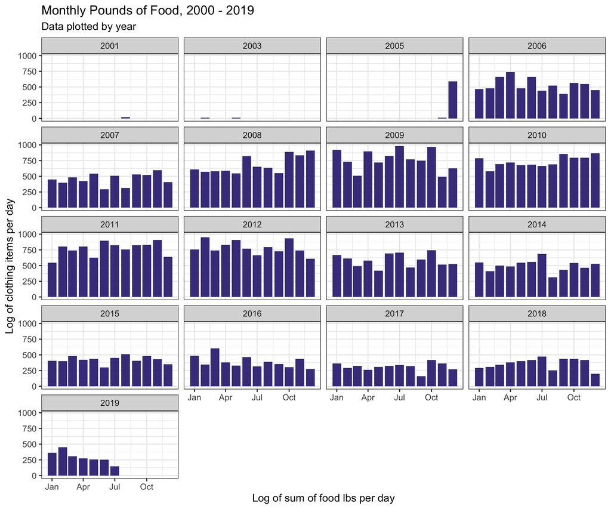

```r
# Plotting yearly food lbs per year on a monthly basis, using bar graph
# help from:
# https://www.earthdatascience.org/courses/earth-analytics/time-series-data/summarize-time-series-by-month-in-r/
UMD_food %>% # create new monthly variable for bar graph
  mutate(month2 = as.Date(paste0("2019-", Month, "-01"), "%Y-%m-%d")) %>% # 2019 and 01 are dummy numbers, just trying to use format for month
  ggplot(aes(x = month2, y = food_pounds_sum)) +
  geom_bar(stat = "identity", fill = "darkslateblue") +
  facet_wrap(~ Year, ncol = 4) +
  labs(title = "Monthly Pounds of Food, 2000 - 2019",
       subtitle = "Data plotted by year",
       x = "Log of sum of food lbs per day",
       y = "Log of clothing items per day") + theme_bw(base_size = 15) +
  scale_x_date(date_labels = "%b")
```

Next, I can explore the relationship between clothing items given with pounds of food provided looking at *daily* sums. I will even find the correlation coefficient. I will compare both the visualization and the correlation coefficient for the raw sum, as well as a log transformed version of the variables.

```r
# now explore relationship between clothes items and food pounds on a daily basis
# find correlation coefficient, rounded to nearest 3 decimals
round(cor(UMD_food$clothes_sum, UMD_food$food_pounds_sum, method = "pearson"), 3)
```

```
## [1] 0.786
```

```r
# plot sums of clothes and food pounds
p1 <- UMD_food %>%
  ggplot(aes(x = clothes_sum, y = food_pounds_sum)) +
    geom_point(color = "darkslateblue", alpha = 1/3) +
    geom_smooth(se = FALSE, color = "deeppink3") +
    labs(title = "Daily Sums of Clothes Items\n and Food lbs, 2000 - 2019",
         x = "Sum of clothes Items per day",
         y = "Sum of food lbs per day") +
    annotate("text", x = 150, y = 50, label = "r = 0.786")

# correlation coefficient, log transformed
round(cor(log2(UMD_food$clothes_sum),log2(UMD_food$food_pounds_sum)), 3)
```

```
## [1] 0.769
```

```r
# same variables, but log transformed
p2  <- UMD_food %>%
  ggplot(aes(x = log2(clothes_sum), y = log2(food_pounds_sum))) +
  geom_point(color = "darkslateblue", alpha = 1/3) +
  geom_smooth(se = FALSE, color = "deeppink3") +
  labs(title = "Sums of Clothes Items and Food lbs \n(Log Transformed), 2000 - 2019",
       x = "Log of daily summed clothes items",
       y = "Log of daily summed food lbs") +
  annotate("text", x = 5, y = 2, label = "r = 0.769")
```

I can plot the graphs side by side like this using the `gridExtra` package:

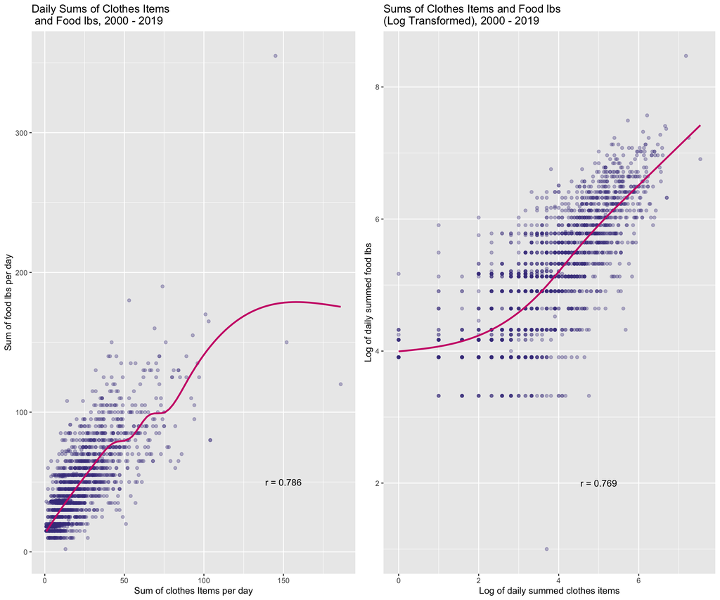

```r
grid.arrange(p1, p2, nrow = 1)
```

Finally, I want to compare the relationship between these variables on a yearly basis. This is similar to the bar graph above, except I am using point data this time.

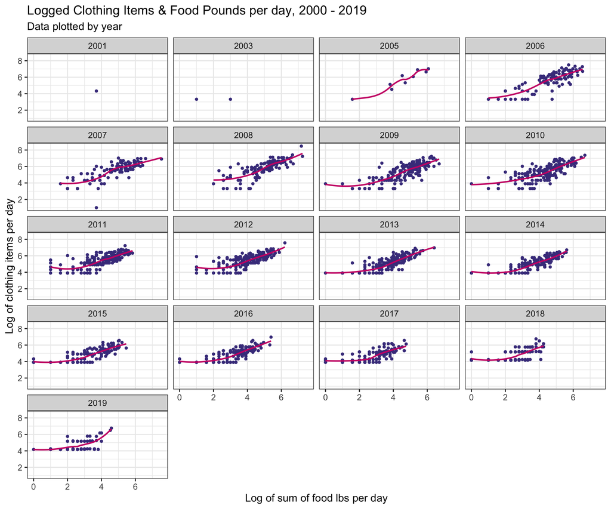

```r
# Explore the relationship between clothes and food lbs on a yearly basis, notice positive trend
# for most years
UMD_food %>%
  ggplot(aes(x = log2(clothes_sum), y = log2(food_pounds_sum))) +
  geom_point(color = "darkslateblue") +
  geom_smooth(se = FALSE, color = "deeppink3") +
  facet_wrap(~ Year, ncol = 4) +
  labs(title = "Logged Clothing Items & Food Pounds per day, 2000 - 2019",
       subtitle = "Data plotted by year",
       x = "Log of sum of food lbs per day",
       y = "Log of clothing items per day") + theme_bw(base_size = 15)
```

There are some variables that I did not explore, like “average amount of people per day” (`ppl_avg`) and the “food pounds per person” (`lbs_per_prsn`), but I can do that in the next iteration of this project!